# Recommendation Systems

## Importing libraries

```python
import numpy as np
import pandas as pd
import matplotlib.pyplot as plt

# %matplotlib inline
plt.style.use("ggplot")

import sklearn
from sklearn.decomposition import TruncatedSVD


import seaborn as sns
from sklearn.neighbors import KNeighborsClassifier

import warnings
warnings.filterwarnings('ignore')

%matplotlib inline
```

## Loading the dataset

```python
amazon_ratings = pd.read_csv('ratings_Electronics.csv')
amazon_ratings.columns = ['UserId','ProductId','Rating','Timestamp']
amazon_ratings = amazon_ratings.dropna()
amazon_ratings.head()
```

|  | UserId | ProductId | Rating | Timestamp |
| --- | --- | --- | --- | --- |
| 0 | A2CX7LUOHB2NDG | 0321732944 | 5.0 | 1341100800 |
| 1 | A2NWSAGRHCP8N5 | 0439886341 | 1.0 | 1367193600 |
| 2 | A2WNBOD3WNDNKT | 0439886341 | 3.0 | 1374451200 |
| 3 | A1GI0U4ZRJA8WN | 0439886341 | 1.0 | 1334707200 |
| 4 | A1QGNMC6O1VW39 | 0511189877 | 5.0 | 1397433600 |

## Data exploration

```python
# Checking shape of data
print("Shape: %s" % str(amazon_ratings.shape))
print("Column names: %s" % str(amazon_ratings.columns))
```

```
Shape: (7824481, 4)
Column names: Index(['UserId', 'ProductId', 'Rating', 'Timestamp'], dtype='object')
```

```python
amazon_ratings.shape
```

```
(7824481, 4)
```

```python
# Checking Unique Users and Products

print("Unique UserID count: %s" % str(amazon_ratings.UserId.nunique()))
print("Unique ProductID count: %s" % str(amazon_ratings.ProductId.nunique()))
```

```
Unique UserID count: 4201696
Unique ProductID count: 476001
```

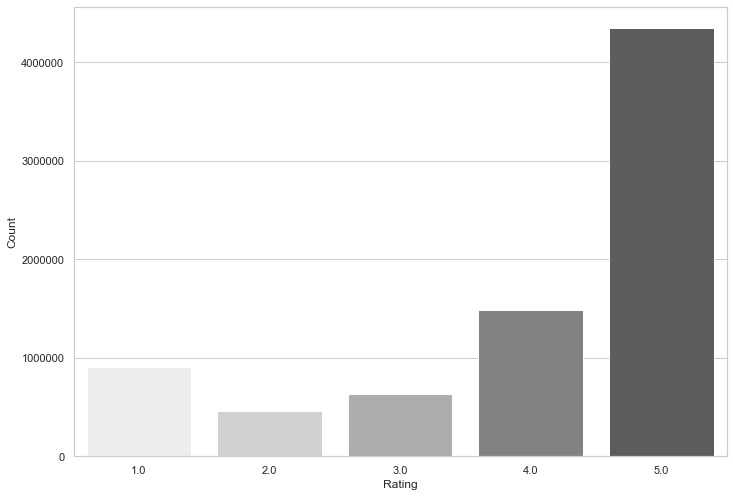

```python
# Checking Rating frequency

sns.set(rc={'figure.figsize': (11.7, 8.27)})
sns.set_style('whitegrid')
ax = sns.countplot(x='Rating', data=amazon_ratings, palette=sns.color_palette('Greys'))
ax.set(xlabel='Rating', ylabel='Count')
plt.show()
```

## Data wrangling

Creating fields and measures form the existing data

This helps generate more data points and validates the idealogy

```python
# Storing Mean rating for each Product

product_rating = amazon_ratings.groupby('ProductId')['Rating'].mean()
product_rating.head()
```

```
ProductId
0321732944    5.000000
0439886341    1.666667
0511189877    4.500000
0528881469    2.851852
0558835155    3.000000
Name: Rating, dtype: float64
```

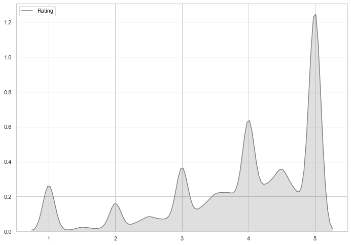

```python
# Plotting KDE distribution of Mean rating

ax = sns.kdeplot(product_rating, shade=True, color='grey')
plt.show()
```

```python
# Counting the number of ratings per Product

product_rating_count = amazon_ratings.groupby('ProductId')['Rating'].count()
product_rating_count.head()
```

```
ProductId
0321732944     1
0439886341     3
0511189877     6
0528881469    27
0558835155     1
Name: Rating, dtype: int64
```

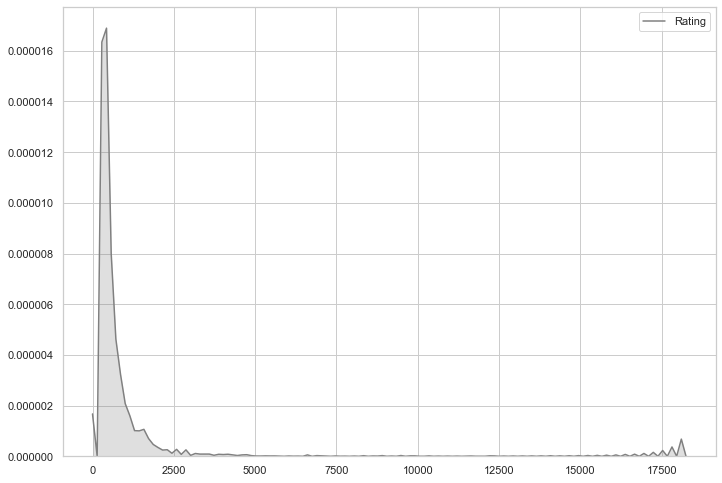

```python
# Plotting KDE distribution of Number of ratings per product

ax = sns.kdeplot(product_rating_count, shade=True, color='grey')
plt.show()
```

```python
# Storing the Un-Reliability factor

unreliability = amazon_ratings.groupby('ProductId')['Rating'].std(ddof = -1)
unreliability.head()
```

```
ProductId
0321732944    0.000000
0439886341    0.816497
0511189877    1.035098
0528881469    1.619164
0558835155    0.000000
Name: Rating, dtype: float64
```

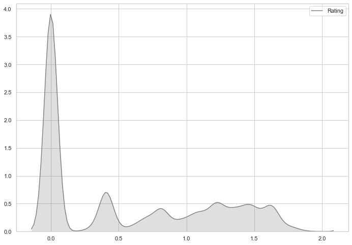

```python
# Plotting the KDE distribution of Un-Reliability factor

ax = sns.kdeplot(unreliability, shade=True, color='grey')
plt.show()
```

The plot show that a large portion of the products are highly reliable. For this unreliabilit factor we used standard devaiation. But we noticed above that a large porition of the Products have a single review. These items have varying ratings but high reliability. This issue needs to tbe addressed.

## Data transforming

Creating a final collection of all the various measures and features for each product

```python
unique_products_list = amazon_ratings.ProductId.unique()
data_model = pd.DataFrame({'Rating': product_rating[unique_products_list],\
                           'Count': product_rating_count[unique_products_list], \
                          'Unreliability': unreliability[unique_products_list]})
data_model.head()
```

| ProductId | Rating | Count | Unreliability |
| --- | --- | --- | --- |
| 0321732944 | 5.000000 | 1 | 0.000000 |
| 0439886341 | 1.666667 | 3 | 0.816497 |
| 0511189877 | 4.500000 | 6 | 1.035098 |
| 0528881469 | 2.851852 | 27 | 1.619164 |
| 0558835155 | 3.000000 | 1 | 0.000000 |

Exploring the data model further

```python
print("Data model shape (number of data points): %s" % str(data_model.shape))
```

```
Data model shape (number of data points): (476001, 3)
```

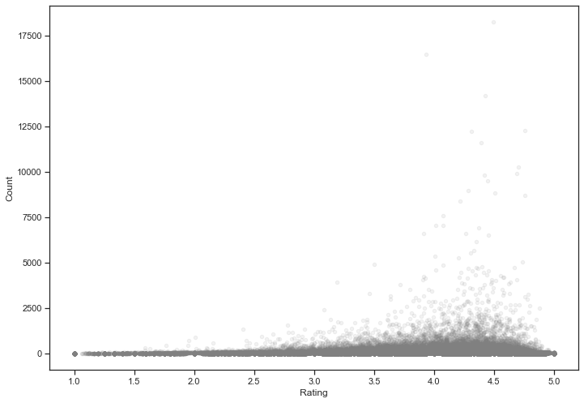

```python
# Plotting Rating versus count

sns.set_style('ticks')
plt.figure(num=None, figsize=(11.7, 8.27), dpi=100, facecolor='w', edgecolor='k')

ax = data_model.plot(kind='scatter', x='Rating', y='Count', color='grey', alpha=0.1)
plt.show()
```

This plot fails to provide much information due to the large number of data points leading to clustered data.

Breaking it down into a number of ranges

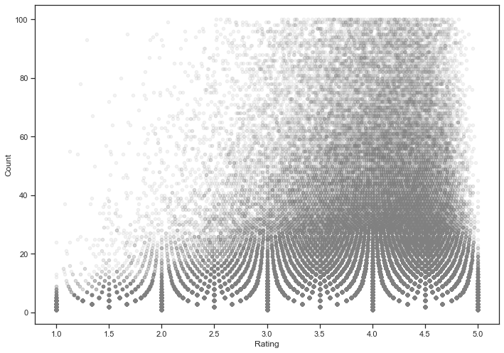

```python
# Less than 100 ratings

ax = data_model[data_model.Count < 101].plot(kind='scatter', x='Rating', y='Count', color='grey', alpha=0.1)
plt.show()
```

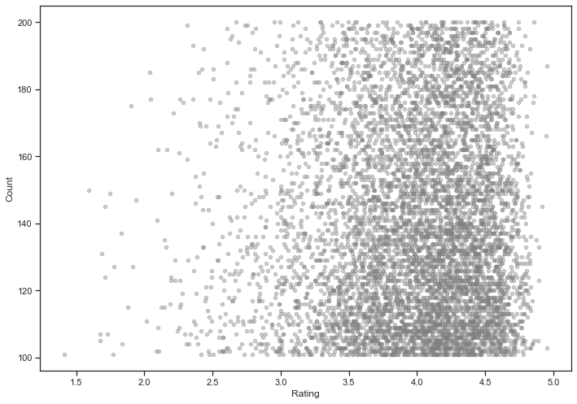

```python
# 100 to 200 ratings

ax = data_model[data_model.Count > 100]\
[data_model.Count<201].plot(kind='scatter', x='Rating', y='Count', color='grey', alpha=0.4)
plt.show()
```

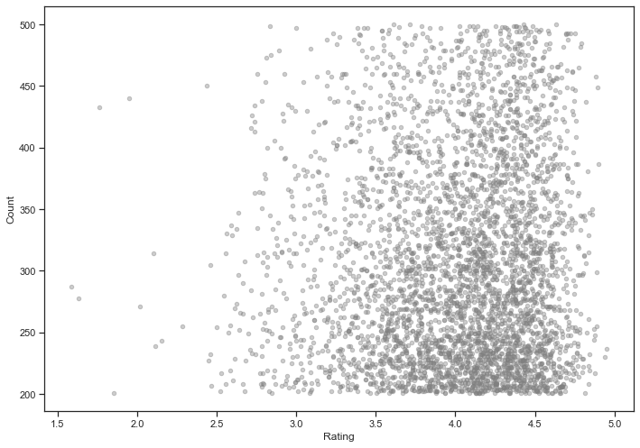

```python
# 200 to 500 ratings

ax = data_model[data_model.Count > 200]\
[data_model.Count<501].plot(kind='scatter', x='Rating', y='Count', color='grey', alpha=0.4)
plt.show()
```

Its noticable that the density becomes sparse as the number of ratings (count) increases.

Exploring corelation between unreliability and the count of ratings and mean rating of the Product.

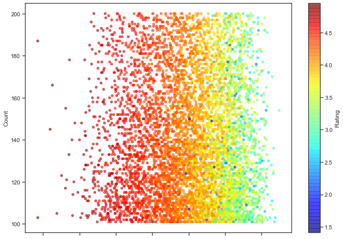

```python
# Adding unreliability factor to the above plots 100 to 200 ratings

ax = data_model[data_model.Count > 100]\
[data_model.Count<201].plot(kind='scatter', x='Unreliability', y='Count', c='Rating', cmap='jet', alpha=0.6)
plt.show()
```

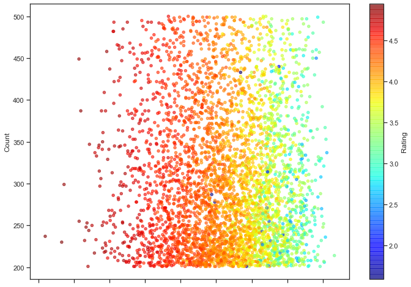

```python
# Addding unreliability factor to the above plots 200 to 500 ratings

ax = data_model[data_model.Count > 200]\
[data_model.Count<501].plot(kind='scatter', x='Unreliability', y='Count', c='Rating', cmap='jet', alpha=0.6)
plt.show()
```

A trend is visible.

Products which have a high unreliability score, seem to have a lower rating over a significant count range.

Exporing corelation between these factors.

```python
# Calculating Coefficient of corelation between Unreliability and Rating

coeff_corelation = np.corrcoef(x=data_model.Unreliability, y=data_model.Rating)
print("Coefficient of corelation: ")
print(coeff_corelation)
```

```
Coefficient of corelation:
[[ 1.        -0.2222165]
 [-0.2222165  1.       ]]
```

This is an insightful indicator as it clarifies questions regarding unreliability.

## Data modelling

Checking feasibility to make prediction. As a fallback, data would need to be modelled into an appropriate format.

```python
# Summarising Count

print(data_model.Count.describe())
```

```
count    476001.000000
mean         16.437951
std         112.702749
min           1.000000
25%           1.000000
50%           2.000000
75%           7.000000
max       18244.000000
Name: Count, dtype: float64
```

```python
# Summarisinge Rating

print(data_model.Rating.describe())
```

```
count    476001.000000
mean          3.889698
std           1.128719
min           1.000000
25%           3.272727
50%           4.000000
75%           5.000000
max           5.000000
Name: Rating, dtype: float64
```

```python
# Summarising Unreliability

print(data_model.Unreliability.describe())
```

```
count    476001.000000
mean          0.563087
std           0.617430
min           0.000000
25%           0.000000
50%           0.408248
75%           1.188967
max           1.940285
Name: Unreliability, dtype: float64
```

It can be concluded that:

These values cannot be use directly as they have a vastly varying range.

```python
# Removing outliers and improbable data points

data_model = data_model[data_model.Count > 50][data_model.Count < 1001].copy()
print(data_model.shape)
```

```
(25093, 3)
```

```python
# Normalization function to range 0 - 10

def normalize(values):
    mn = values.min()
    mx = values.max()
    return(10.0/(mx - mn) * (values - mx)+10)
```

```python
data_model_norm = normalize(data_model)
data_model_norm.head()
```

| ProductId | Rating | Count | Unreliability |
| --- | --- | --- | --- |
| 1400501466 | 6.313657 | 2.096944 | 8.245284 |
| 1400501520 | 8.088588 | 0.326660 | 6.736522 |
| 1400501776 | 7.156849 | 0.927292 | 6.945501 |
| 1400532620 | 6.636020 | 1.264489 | 8.278920 |
| 1400532655 | 6.747779 | 4.562698 | 7.690769 |

## Recommendation System - Method 1

With the normalized data model, system can recomend similar items based on:

Count of ratings

Mean rating

Unreliability factor

```python
# Setting up the model

# Recommend 20 similar items
engine = KNeighborsClassifier(n_neighbors=20)

# Training data points
data_points = data_model_norm[['Count', 'Rating', 'Unreliability']].values

#Training labels
labels = data_model_norm.index.values

print("Data points: ")
print(data_points)
print("Labels: ")
print(labels)

engine.fit(data_points, labels)
```

```
Data points:
[[2.09694415 6.31365655 8.24528378]
 [0.32665964 8.0885884  6.73652205]
 [0.92729189 7.15684891 6.94550086]
 ...
 [0.01053741 6.35757701 8.08456231]
 [0.07376185 6.51591095 8.2027859 ]
 [0.20021075 9.56890399 3.275159  ]]
Labels:
['1400501466' '1400501520' '1400501776' ... 'B00KINSDK8' 'B00KWHMR6G'
 'B00L3YHF6O']
```

```
KNeighborsClassifier(algorithm='auto', leaf_size=30, metric='minkowski',
                     metric_params=None, n_jobs=None, n_neighbors=20, p=2,
                     weights='uniform')
```

The recommendation engine is setup and has been initialized with the required data points and labels.

It can be used to recommend a list of 20 similar items

```
Recommended products:
[Index(['B00L3YHF6O', 'B00870KSOI', 'B000SDPMEI', 'B00142MUDI', 'B001F0MFXY'], dtype='object', name='ProductId')]
```

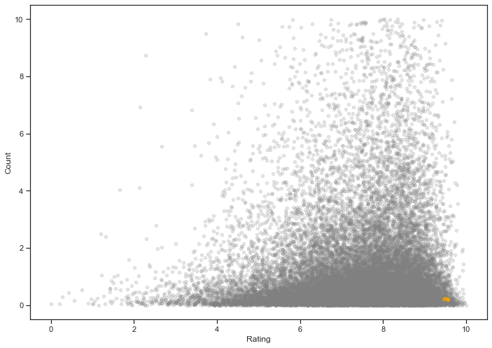

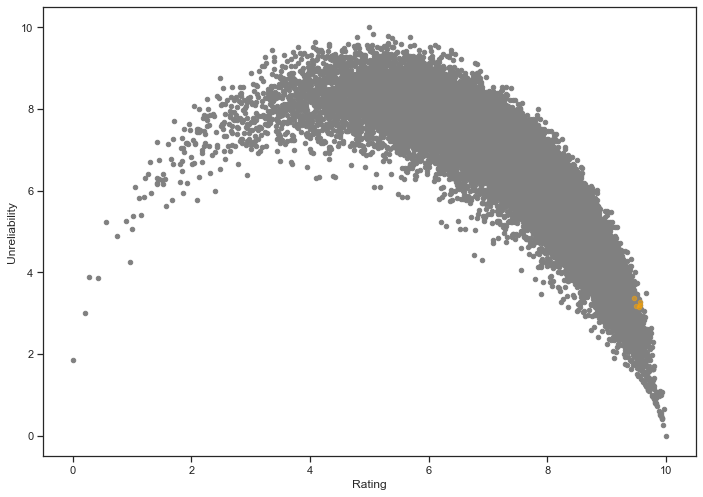

```python
# Entering a dummy product ID to get a list of 5 recommended items

# User entered value
product_id = 'B00L3YHF6O'

product_data = [data_model_norm.loc[product_id][['Count', 'Rating', 'Unreliability']].values]

recommended_products = engine.kneighbors(X=product_data, n_neighbors=5, return_distance=False)

# List of product IDs form the indexes

products_list = []

for each in recommended_products:
    products_list.append(data_model_norm.iloc[each].index)

print("Recommended products: ")
print(products_list)

# Showing recommended products

ax = data_model_norm.plot(kind='scatter', x='Rating', y='Count', color='grey', alpha=0.20)
data_model_norm.iloc[recommended_products[0]].plot(kind='scatter', x='Rating', y='Count',\
                                                   color='orange', alpha=0.5, ax=ax)

ax2 = data_model_norm.plot(kind='scatter', x='Rating', y='Unreliability', color='grey')
data_model_norm.iloc[recommended_products[0]].plot(kind='scatter', x='Rating', y='Unreliability',\
                                                   color='orange', alpha=0.5, ax=ax2)
plt.show()

##The below 5 products are the recommended ones as per Method 1 and are also highlighted in the plot.
```

## Recommendation System - Method 2 - Part I

Product popularity based recommendation system targeted at new customers

It can be a great strategy to target the new customers with the most popular products sold on the business's website and is very useful to cold start a recommendation engine.

```python
popular_products = pd.DataFrame(amazon_ratings.groupby('ProductId')['Rating'].count())
most_popular = popular_products.sort_values('Rating', ascending=False)
most_popular.head(10)
```

| ProductId | Rating |
| --- | --- |
| B0074BW614 | 18244 |
| B00DR0PDNE | 16454 |
| B007WTAJTO | 14172 |
| B0019EHU8G | 12285 |
| B006GWO5WK | 12226 |
| B003ELYQGG | 11617 |
| B003ES5ZUU | 10276 |
| B007R5YDYA | 9907 |
| B00622AG6S | 9823 |
| B0002L5R78 | 9487 |

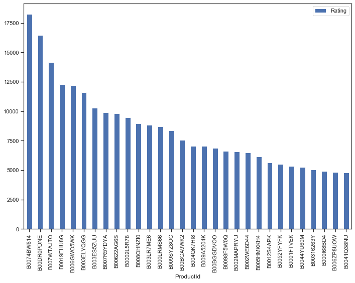

```python
most_popular.head(30).plot(kind = "bar")
```

Analysis:

The above graph gives us the most popular products (arranged in descending order) sold by the business.

For eaxmple, product, ID # B0074BW614 has sales of over 17500, the next most popular product, ID # B00DR0PDNE has sales of over 16000, etc.

## Recommendation System - Part II

Model-based collaborative filtering system

It can be used to recommend items to users based on purchase history and similarity of ratings provided by other users who bought items to that of a particular customer.

A model based collaborative filtering technique is chosen here as it helps in making predicting products for a particular user by identifying patterns based on preferences from multiple user data.

Utility Matrix based on products sold and user reviews

A utlity matrix will consist of all possible user-item preferences (ratings) details represented as a matrix. The utility matrix will be sparce as none of the users would buy all the items in the list, hence, most of the values are unknown.

```python
# Subset of Amazon Ratings

amazon_ratings1 = amazon_ratings.head(10000)
```

```python
ratings_utility_matrix = amazon_ratings1.pivot_table(values='Rating', index='UserId', columns='ProductId', fill_value=0)
ratings_utility_matrix.head()
```

| ProductId UserId | 0321732944 | 0439886341 | 0511189877 | 0528881469 | 0558835155 | 059400232X | 0594012015 | 0594017343 | 0594017580 | 0594033896 | ... | B00000J1DN | B00000J1DT | B00000J1E6 | B00000J1EC | B00000J1EJ | B00000J1EP | B00000J1EQ | B00000J1ES | B00000J1EZ | B00000J1F3 |
| --- | --- | --- | --- | --- | --- | --- | --- | --- | --- | --- | --- | --- | --- | --- | --- | --- | --- | --- | --- | --- | --- |
| A00766851QZZUBOVF4JFT | 0 | 0 | 0 | 0 | 0 | 0 | 0 | 0 | 0 | 0 | ... | 0 | 0 | 0 | 0 | 0 | 0 | 0 | 0 | 0 | 0 |
| A01255851ZO1U93P8RKGE | 0 | 0 | 0 | 0 | 0 | 0 | 0 | 0 | 0 | 0 | ... | 0 | 0 | 0 | 0 | 0 | 0 | 0 | 0 | 0 | 0 |
| A0293130VTX2ZXA70JQS | 0 | 0 | 0 | 0 | 0 | 0 | 0 | 0 | 0 | 0 | ... | 0 | 0 | 0 | 0 | 0 | 0 | 0 | 0 | 0 | 0 |
| A030530627MK66BD8V4LN | 0 | 0 | 0 | 0 | 0 | 0 | 0 | 0 | 0 | 0 | ... | 0 | 0 | 0 | 0 | 0 | 0 | 0 | 0 | 0 | 0 |
| A0402564TCEO67AUZFJO | 0 | 0 | 0 | 0 | 0 | 0 | 0 | 0 | 0 | 0 | ... | 0 | 0 | 0 | 0 | 0 | 0 | 0 | 0 | 0 | 0 |

5 rows × 1304 columns

As expected, the utility matrix obtaned above is sparce, the unknown values have been replaced with 0.

```python
ratings_utility_matrix.shape
```

```
(9826, 1304)
```

## Transposing the matrix

```python
X = ratings_utility_matrix.T
X.head()
```

| UserId ProductId | A00766851QZZUBOVF4JFT | A01255851ZO1U93P8RKGE | A0293130VTX2ZXA70JQS | A030530627MK66BD8V4LN | A0402564TCEO67AUZFJO | A04256643L1ZMT75HVD2P | A0590501PZ7HOWJKBGQ4 | A0641581307AKT5MAOU0Q | A076219533YHEV2LJO988 | A07865442XT0VEAVPSGX1 | ... | AZV9WA9MNT0FB | AZX0ZDVAFMN78 | AZX5LAN9JEAFF | AZX7I110AF0W2 | AZXFQVG0PS3V1 | AZYNQZ94U6VDB | AZYTSU42BZ7TP | AZZ77XYX8O2WE | AZZGUU97OHUF1 | AZZMV5VT9W7Y8 |
| --- | --- | --- | --- | --- | --- | --- | --- | --- | --- | --- | --- | --- | --- | --- | --- | --- | --- | --- | --- | --- | --- |
| 0321732944 | 0 | 0 | 0 | 0 | 0 | 0 | 0 | 0 | 0 | 0 | ... | 0 | 0 | 0 | 0 | 0 | 0 | 0 | 0 | 0 | 0 |
| 0439886341 | 0 | 0 | 0 | 0 | 0 | 0 | 0 | 0 | 0 | 0 | ... | 0 | 0 | 0 | 0 | 0 | 0 | 0 | 0 | 0 | 0 |
| 0511189877 | 0 | 0 | 0 | 0 | 0 | 0 | 0 | 0 | 0 | 0 | ... | 0 | 0 | 0 | 0 | 0 | 5 | 0 | 0 | 0 | 0 |
| 0528881469 | 0 | 0 | 0 | 0 | 0 | 0 | 0 | 0 | 0 | 0 | ... | 0 | 0 | 0 | 0 | 0 | 0 | 0 | 0 | 0 | 0 |
| 0558835155 | 0 | 0 | 0 | 0 | 0 | 0 | 0 | 0 | 0 | 0 | ... | 0 | 0 | 0 | 0 | 0 | 0 | 0 | 0 | 0 | 0 |

5 rows × 9826 columns

```python
X.shape
```

```
(1304, 9826)
```

Unique products in subset of data

```python
X1 = X
```

## Decomposing the Matrix

```python
SVD = TruncatedSVD(n_components=10)
decomposed_matrix = SVD.fit_transform(X)
decomposed_matrix.shape
```

```
(1304, 10)
```

## Correlation Matrix

```python
correlation_matrix = np.corrcoef(decomposed_matrix)
correlation_matrix.shape
```

```
(1304, 1304)
```

## Correlation_matrix

Isolating Product ID # 1616833742 from the Correlation Matrix

Assuming the customer buys Product ID # 1616833742 (randomly chosen)

```python
X.index[99]
```

```
'1616833742'
```

Index # of product ID purchased by customer

```python
i = "1616833742"

product_names = list(X.index)
product_ID = product_names.index(i)
product_ID
```

```
99
```

Correlation for all items with the item purchased by this customer based on items rated by other customers people who bought the same product

```python
correlation_product_ID = correlation_matrix[product_ID]
correlation_product_ID.shape
```

```
(1304,)
```

```python
Recommend = list(X.index[correlation_product_ID > 0.95])

# Removes the item already bought by the customer
Recommend.remove(i)

Recommend[0:5]
```

```
['0321732944', '9810521510', '9966279008', '9966289941', '9966528865']
```

Product Id # of the top 5 products that can be displayed by the recommendation system to the above customer based on the purchase history of other customers on the website.

## Conclusion

The engine recommends similar products based on feature such as number of ratings, mean ratings and unreliability factor of the Product.

As seen from the above output, we can alter the number of items recommended, and using this we can integrate online sales trends into retails stores by recommending similar products to the store.

This also can be used as an added feature as a plus point when discussing item sales and profits with the stores.